# homework #7

Jianwen Wu ECO B2000 Prof.Kevin Foster

1. What are the names of the people currently in your study group? Crystal Hernandez
2. Each person in the group should find 2 academic articles related to your current choice of final project. Write a short paragraph on each, concentrating on what data is used (and whether it is accessible), what econometric techniques, and what questions are addressed.

Article 1: Time-Varying Effects of Oil Supply Shocks on the US Economy: Author(s): Christiane Baumeister and Gert Peersman: Source: American Economic Journal: Macroeconomics, Vol. 5, No. 4 (October 2013), pp. 1-28 Published by: American Economic Association: Stable URL: http://www.jstor.org/stable/43189560:

This paper aims to find a relationship between oil prices and macroeconomic activity since 1974. They also seek to analyze time varying effects that may arise from legislation passed on energy markets or changes in the automotive sector. The authors use a time series model with varying structural parameters to find the how effects of “shocks” in oil supply effect the US economy over time. The authors sought to change and expand on the work of Cogley and Sargent (2005), Primiceri (2005), and Benati and Mumtaz (2007), among others who instead analyzed the data by splitting the sample in half and estimating the bivartiate Var on rolling windows. The authors of this paper believed that this approach was not affective when dealing with structural change. They inferred that the rolling-window approach replied on samples that caused a simple degrees of freedom problem when estimating the reduced high-dimensional VAR model. In order to deal with these issues the authors used estimated by a multivariate structural VAR with time-varying parameter. The sought to show that oil supply shock in the time- varying parameter model can be normalized to hold constant across time in the real price of oil on impact. The authors found that volality of oil prices by supply shock has decreased over time, implying that oil shocks are not main cause of oil price movement in more recent years. The data for this paper was obtained from the US Energy Information Administration’s (EIA) and Bureau of Labor Statistics both respectively saved to their online database.

Article 2 Oil Price Uncertainty; Author(s): JOHN ELDER and APOSTOLOS SERLETIS; Source: Journal of Money, Credit and Banking, Vol. 42, No. 6 (September 2010), pp. 1137-1159Published by: Wiley; Stable URL: http://www.jstor.org/stable/40784879

In this paper, we examine the direct effects of oil price uncertainty on real economic – Summary: This article seeks to look at the empirical relationship between uncertainty in oil prices (that can affect economic activity) and investments. The authors of this paper argue that the relationship between oil prices and economic activity is nonlinear, and that the continued increases in the price of oil have different outcomes than those with brief fluctuations or continued decreases. They believe that increases in oil prices, lead to higher overall costs, which cause a reduction of household and firm capital, that lead to aggregate demand. In this paper, the authors used a dynamic bivariate and structural vector autoregression model with some modifications to allow for bivariate generalized autoregressive conditional heteroscedasticity GARCH-in-mean errors. For the measure of uncertainty on the oil prices, the authors used the “conditional standard deviation of the forecast error” to determine differences in the oil prices. The authors’ results suggest that uncertainty regarding oil prices has an significant effect on GDP and many portions of fixed investments. There data suggests that incertainty in oil prices in the can decrease investment. The data used in their analysis was obtained by the Department of Energy, and is available on their website (https://www.eia.gov/dnav/pet/PET_CRD_CRPDN_ADC_MBBL_M.htm)

3. This question uses the power of combinations. Pick a dataset from column 1 and some estimation technique from column 2 and show me some nice results. Continue. Impress me. (There are 77 combinations here; you can bet that at least one of them [prob more] will be on exam.)

```r
load("/Users/jianwenwu/Desktop/ECO B2000/Dataset/PUMSdata/pums_NY.RData")
require(quantreg)
attach(dat_pums_NY)
```

```r
primeAge <- (Age >= 25) & (Age <= 55) & work_fullyr

dat_prime <- subset(dat_pums_NY,primeAge)
detach(dat_pums_NY)
attach(dat_prime)
```

We would like to look at the 10%, 25%, 50%, 75%, and 90% quantile of total income Wage or Salary.

```r
Y<-cbind(income_wagesal)
X<-cbind(Age , female , AfAm , educ_hs , educ_smcoll , educ_as , educ_bach ,educ_adv)

quantilereg10<-rq(Y ~ X, tau= 0.10, data=dat_prime)
quantilereg25<-rq(Y ~ X, tau= 0.25, data=dat_prime)
quantilereg50<-rq(Y ~ X, tau= 0.50, data=dat_prime)
quantilereg75<-rq(Y ~ X, tau= 0.75, data=dat_prime)
quantilereg90<-rq(Y ~ X, tau= 0.90, data=dat_prime)

summary(quantilereg10)
```

```
##
## Call: rq(formula = Y ~ X, tau = 0.1, data = dat_prime)
##
## tau: [1] 0.1
##
## Coefficients:
##              Value       Std. Error  t value     Pr(>|t|)
## (Intercept)   3411.76471   910.41612     3.74748     0.00018
## XAge            47.05882    17.46424     2.69458     0.00705
## Xfemale      -3650.00000   352.34016   -10.35931     0.00000
## XAfAm         1350.00000   330.74321     4.08172     0.00004
## Xeduc_hs      5270.58824   626.88449     8.40759     0.00000
## Xeduc_smcoll  9061.76471   661.21146    13.70479     0.00000
## Xeduc_as     10223.52941   699.25590    14.62058     0.00000
## Xeduc_bach   13308.82353   714.71546    18.62115     0.00000
## Xeduc_adv    20270.58824  1049.36137    19.31707     0.00000
```

```r
summary(quantilereg25)
```

```
##
## Call: rq(formula = Y ~ X, tau = 0.25, data = dat_prime)
##
## tau: [1] 0.25
##
## Coefficients:
##              Value       Std. Error  t value     Pr(>|t|)
## (Intercept)   2156.25000   466.31095     4.62406     0.00000
## XAge           343.75000    12.21148    28.14973     0.00000
## Xfemale      -8281.25000   229.06877   -36.15181     0.00000
## XAfAm          -31.25000   255.53455    -0.12229     0.90267
## Xeduc_hs      6750.00000   218.20817    30.93376     0.00000
## Xeduc_smcoll 13156.25000   297.43276    44.23269     0.00000
## Xeduc_as     15625.00000   401.65792    38.90126     0.00000
## Xeduc_bach   24437.50000   387.01108    63.14419     0.00000
## Xeduc_adv    37218.75000   490.72320    75.84469     0.00000
```

```r
summary(quantilereg50)
```

```
##
## Call: rq(formula = Y ~ X, tau = 0.5, data = dat_prime)
##
## tau: [1] 0.5
##
## Coefficients:
##              Value        Std. Error   t value      Pr(>|t|)
## (Intercept)    1353.84615    597.91850      2.26427      0.02356
## XAge            630.76923     14.63397     43.10307      0.00000
## Xfemale      -13646.15385    267.64813    -50.98543      0.00000
## XAfAm         -1461.53846    319.52142     -4.57415      0.00000
## Xeduc_hs      10861.53846    315.64962     34.41011      0.00000
## Xeduc_smcoll  18738.46154    380.78207     49.21046      0.00000
## Xeduc_as      22523.07692    427.61335     52.67159      0.00000
## Xeduc_bach    39000.00000    448.65039     86.92737      0.00000
## Xeduc_adv     53369.23077    565.25489     94.41622      0.00000
```

```r
summary(quantilereg75)
```

```
##
## Call: rq(formula = Y ~ X, tau = 0.75, data = dat_prime)
##
## tau: [1] 0.75
##
## Coefficients:
##              Value        Std. Error   t value      Pr(>|t|)
## (Intercept)    3933.33333   1000.08138      3.93301      0.00008
## XAge            925.64103     21.73191     42.59363      0.00000
## Xfemale      -19317.94872    419.16114    -46.08716      0.00000
## XAfAm         -3351.28205    488.51397     -6.86016      0.00000
## Xeduc_hs      13987.17949    552.70338     25.30685      0.00000
## Xeduc_smcoll  23879.48718    575.94762     41.46121      0.00000
## Xeduc_as      29284.61538    686.25955     42.67280      0.00000
## Xeduc_bach    55784.61538    766.14786     72.81181      0.00000
## Xeduc_adv     74966.66667   1102.44625     68.00029      0.00000
```

```r
summary(quantilereg90)
```

```
##
## Call: rq(formula = Y ~ X, tau = 0.9, data = dat_prime)
##
## tau: [1] 0.9
##
## Coefficients:
##              Value        Std. Error   t value      Pr(>|t|)
## (Intercept)   15973.91304   2068.31339      7.72316      0.00000
## XAge           1217.39130     42.80380     28.44120      0.00000
## Xfemale      -31739.13043    803.75667    -39.48848      0.00000
## XAfAm         -5000.00000    904.27253     -5.52931      0.00000
## Xeduc_hs      14678.26087   1222.26291     12.00909      0.00000
## Xeduc_smcoll  28026.08696   1289.24039     21.73845      0.00000
## Xeduc_as      35460.86957   1427.78585     24.83627      0.00000
## Xeduc_bach    77895.65217   1590.08819     48.98826      0.00000
## Xeduc_adv    124373.91304   2716.64225     45.78222      0.00000
```

```r
require("stargazer")
stargazer(quantilereg10,quantilereg25, quantilereg50,quantilereg75,quantilereg90, type = "text" ,title="Results",align=TRUE)
```

```
##
## Results
## =====================================================================================
##                                        Dependent variable:
##              ------------------------------------------------------------------------
##                                                 Y
##                   (1)           (2)           (3)            (4)            (5)
## -------------------------------------------------------------------------------------
## XAge           47.059***    343.750***     630.769***     925.641***    1,217.391***
##                (17.464)      (12.211)       (14.634)       (21.732)       (42.804)
##
## Xfemale      -3,650.000*** -8,281.250*** -13,646.150*** -19,317.950*** -31,739.130***
##                (352.340)     (229.069)     (267.648)      (419.161)      (803.757)
##
## XAfAm        1,350.000***     -31.250    -1,461.538***  -3,351.282***  -5,000.000***
##                (330.743)     (255.535)     (319.521)      (488.514)      (904.273)
##
## Xeduc_hs     5,270.588***  6,750.000***  10,861.540***  13,987.180***  14,678.260***
##                (626.884)     (218.208)     (315.650)      (552.703)     (1,222.263)
##
## Xeduc_smcoll 9,061.765***  13,156.250*** 18,738.460***  23,879.490***  28,026.090***
##                (661.211)     (297.433)     (380.782)      (575.948)     (1,289.240)
##
## Xeduc_as     10,223.530*** 15,625.000*** 22,523.080***  29,284.620***  35,460.870***
##                (699.256)     (401.658)     (427.613)      (686.260)     (1,427.786)
##
## Xeduc_bach   13,308.820*** 24,437.500*** 39,000.000***  55,784.610***  77,895.650***
##                (714.715)     (387.011)     (448.650)      (766.148)     (1,590.088)
##
## Xeduc_adv    20,270.590*** 37,218.750*** 53,369.230***  74,966.670***  124,373.900***
##               (1,049.361)    (490.723)     (565.255)     (1,102.446)    (2,716.642)
##
## Constant     3,411.765***  2,156.250***   1,353.846**    3,933.333***  15,973.910***
##                (910.416)     (466.311)     (597.918)     (1,000.081)    (2,068.313)
##
## -------------------------------------------------------------------------------------
## Observations    51,222        51,222         51,222         51,222         51,222
## =====================================================================================
## Note:                                                     *p<0.1; **p<0.05; ***p<0.01
```

Interpretation of the coefficients:

# Plotting data

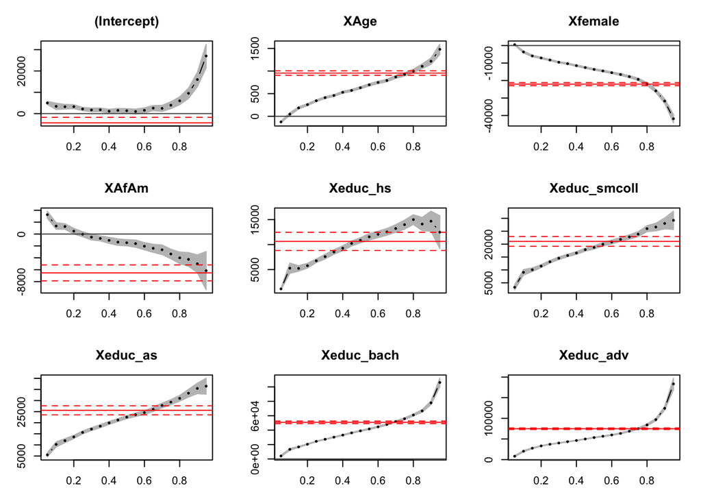

```r
# Plotting data

quantilereg.all <- rq(Y ~ X, tau = seq(0.05, 0.95, by = 0.05), data=dat_prime)
quantilereg.plot <- summary(quantilereg.all)
plot(quantilereg.plot)
```

The plot indicated when will quantile coefficient is outside the OLS confidence interval. If the quantile coefficient is outside the OSL confidence interval,then we have significant differences between the quantile and OLS coefficients.

In the plot (Educ_adv), the red line is the OSL confidence interval and the black line is quantile coefficients confidence interval. Based on the individuals with advance degree plot, we knows that quantile coefficients are significant differences from 0. However, quantile cofficients is not significant different from the OLS coefficient at 70% quantile (when the OSL(Red line) cross the Quantile cofficient(Black line).

```r
detach(dat_prime)
attach(dat_pums_NY)

Y<-cbind(has_AnyHealthIns)
X1 <- cbind(Age,female,white, AfAm, Asian, Hispanic, educ_nohs, educ_hs, educ_smcoll, educ_as, educ_bach, educ_adv, veteran, Married, divwidsep)

summary((Y))
```

```
##  has_AnyHealthIns
##  Min.   :0.0000
##  1st Qu.:1.0000
##  Median :1.0000
##  Mean   :0.9082
##  3rd Qu.:1.0000
##  Max.   :1.0000
```

```r
summary(X1)
```

```
##       Age            female           white             AfAm
##  Min.   : 0.00   Min.   :0.0000   Min.   :0.0000   Min.   :0.0000
##  1st Qu.:20.00   1st Qu.:0.0000   1st Qu.:0.0000   1st Qu.:0.0000
##  Median :41.00   Median :1.0000   Median :1.0000   Median :0.0000
##  Mean   :40.58   Mean   :0.5191   Mean   :0.7093   Mean   :0.1347
##  3rd Qu.:59.00   3rd Qu.:1.0000   3rd Qu.:1.0000   3rd Qu.:0.0000
##  Max.   :94.00   Max.   :1.0000   Max.   :1.0000   Max.   :1.0000
##      Asian            Hispanic        educ_nohs         educ_hs
##  Min.   :0.00000   Min.   :0.0000   Min.   :0.0000   Min.   :0.0000
##  1st Qu.:0.00000   1st Qu.:0.0000   1st Qu.:0.0000   1st Qu.:0.0000
##  Median :0.00000   Median :0.0000   Median :0.0000   Median :0.0000
##  Mean   :0.07088   Mean   :0.1353   Mean   :0.3166   Mean   :0.2196
##  3rd Qu.:0.00000   3rd Qu.:0.0000   3rd Qu.:1.0000   3rd Qu.:0.0000
##  Max.   :1.00000   Max.   :1.0000   Max.   :1.0000   Max.   :1.0000
##   educ_smcoll        educ_as          educ_bach         educ_adv
##  Min.   :0.0000   Min.   :0.00000   Min.   :0.0000   Min.   :0.0000
##  1st Qu.:0.0000   1st Qu.:0.00000   1st Qu.:0.0000   1st Qu.:0.0000
##  Median :0.0000   Median :0.00000   Median :0.0000   Median :0.0000
##  Mean   :0.1576   Mean   :0.06641   Mean   :0.1374   Mean   :0.1025
##  3rd Qu.:0.0000   3rd Qu.:0.00000   3rd Qu.:0.0000   3rd Qu.:0.0000
##  Max.   :1.0000   Max.   :1.00000   Max.   :1.0000   Max.   :1.0000
##     veteran           Married         divwidsep
##  Min.   :0.00000   Min.   :0.0000   Min.   :0.0000
##  1st Qu.:0.00000   1st Qu.:0.0000   1st Qu.:0.0000
##  Median :0.00000   Median :0.0000   Median :0.0000
##  Mean   :0.05515   Mean   :0.3937   Mean   :0.1515
##  3rd Qu.:0.00000   3rd Qu.:1.0000   3rd Qu.:0.0000
##  Max.   :1.00000   Max.   :1.0000   Max.   :1.0000
```

```r
table(Y)
```

```
## Y
##      0      1
##  18029 178285
```

```r
table(Y)/sum(table(Y))
```

```
## Y
##          0          1
## 0.09183757 0.90816243
```

Now, we are going to look at logit regression model

```r
logit<- glm(Y ~ X1, family=binomial (link = "logit"), na.action = na.exclude)

summary(logit)
```

```
##
## Call:
## glm(formula = Y ~ X1, family = binomial(link = "logit"), na.action = na.exclude)
##
## Deviance Residuals:
##     Min       1Q   Median       3Q      Max
## -3.0156   0.2959   0.3822   0.4764   1.1882
##
## Coefficients: (1 not defined because of singularities)
##                 Estimate Std. Error z value Pr(>|z|)
## (Intercept)    2.1803260  0.0500708  43.545  < 2e-16 ***
## X1Age          0.0085777  0.0005589  15.349  < 2e-16 ***
## X1female       0.4601247  0.0164294  28.006  < 2e-16 ***
## X1white        0.4310642  0.0277909  15.511  < 2e-16 ***
## X1AfAm        -0.1025352  0.0325811  -3.147  0.00165 **
## X1Asian       -0.5003093  0.0371916 -13.452  < 2e-16 ***
## X1Hispanic    -0.8369822  0.0232098 -36.062  < 2e-16 ***
## X1educ_nohs   -0.2186374  0.0411380  -5.315 1.07e-07 ***
## X1educ_hs     -1.1170916  0.0394489 -28.317  < 2e-16 ***
## X1educ_smcoll -0.7762138  0.0414525 -18.725  < 2e-16 ***
## X1educ_as     -0.7357664  0.0483170 -15.228  < 2e-16 ***
## X1educ_bach   -0.5337462  0.0431443 -12.371  < 2e-16 ***
## X1educ_adv            NA         NA      NA       NA
## X1veteran      1.1560095  0.0593050  19.493  < 2e-16 ***
## X1Married      0.1855127  0.0233030   7.961 1.71e-15 ***
## X1divwidsep   -0.0551829  0.0308335  -1.790  0.07350 .
## ---
## Signif. codes:  0 '***' 0.001 '**' 0.01 '*' 0.05 '.' 0.1 ' ' 1
##
## (Dispersion parameter for binomial family taken to be 1)
##
##     Null deviance: 120446  on 196313  degrees of freedom
## Residual deviance: 112984  on 196299  degrees of freedom
## AIC: 113014
##
## Number of Fisher Scoring iterations: 6
```

Logit model odds ratios: If the odds ratios is greater than 1, it means that outcome ofhave insurance cover is more likely than outcome of people did not have insurance cover.

```r
exp(logit$coefficients)
```

```
##   (Intercept)         X1Age      X1female       X1white        X1AfAm
##     8.8491906     1.0086146     1.5842715     1.5388943     0.9025464
##       X1Asian    X1Hispanic   X1educ_nohs     X1educ_hs X1educ_smcoll
##     0.6063431     0.4330153     0.8036130     0.3272301     0.4601449
##     X1educ_as   X1educ_bach    X1educ_adv     X1veteran     X1Married
##     0.4791381     0.5864040            NA     3.1772293     1.2038355
##   X1divwidsep
##     0.9463120
```

Probit regression model

```r
probit<- glm(Y~X1, family = binomial(link = "probit"), na.action = na.exclude)
summary(probit)
```

```
##
## Call:
## glm(formula = Y ~ X1, family = binomial(link = "probit"), na.action = na.exclude)
##
## Deviance Residuals:
##     Min       1Q   Median       3Q      Max
## -3.1140   0.2898   0.3820   0.4808   1.1044
##
## Coefficients: (1 not defined because of singularities)
##                 Estimate Std. Error z value Pr(>|z|)
## (Intercept)    1.2206620  0.0246711  49.477  < 2e-16 ***
## X1Age          0.0047675  0.0002812  16.951  < 2e-16 ***
## X1female       0.2336432  0.0084192  27.751  < 2e-16 ***
## X1white        0.2310046  0.0150675  15.331  < 2e-16 ***
## X1AfAm        -0.0482595  0.0176209  -2.739  0.00617 **
## X1Asian       -0.2584278  0.0201422 -12.830  < 2e-16 ***
## X1Hispanic    -0.4465751  0.0124530 -35.861  < 2e-16 ***
## X1educ_nohs   -0.0886235  0.0192397  -4.606 4.10e-06 ***
## X1educ_hs     -0.5448138  0.0185006 -29.448  < 2e-16 ***
## X1educ_smcoll -0.3720171  0.0195373 -19.041  < 2e-16 ***
## X1educ_as     -0.3507548  0.0231448 -15.155  < 2e-16 ***
## X1educ_bach   -0.2466529  0.0202404 -12.186  < 2e-16 ***
## X1educ_adv            NA         NA      NA       NA
## X1veteran      0.5470919  0.0263926  20.729  < 2e-16 ***
## X1Married      0.0933311  0.0119705   7.797 6.35e-15 ***
## X1divwidsep   -0.0392417  0.0158474  -2.476  0.01328 *
## ---
## Signif. codes:  0 '***' 0.001 '**' 0.01 '*' 0.05 '.' 0.1 ' ' 1
##
## (Dispersion parameter for binomial family taken to be 1)
##
##     Null deviance: 120446  on 196313  degrees of freedom
## Residual deviance: 112923  on 196299  degrees of freedom
## AIC: 112953
##
## Number of Fisher Scoring iterations: 6
```

```r
LogitScalar <- mean(dlogis(predict(logit, type = "link"))) #average of predict value
LogitScalar
```

```
## [1] 0.0798251
```

```r
AVG_MarginalLogit<-LogitScalar * coef(logit)
```

Probit model average mariginal effects

```r
# Probit model average marginal effects
ProbitScalar <- mean(dnorm(predict(probit, type = "link")))
ProbitScalar
```

```
## [1] 0.1549923
```

```r
AVG_MarginalProbit<-ProbitScalar * coef(probit)
```

logit model predicted probabilities

```r
plogit<-predict(logit, type="response")
summary(plogit)
```

```
##    Min. 1st Qu.  Median    Mean 3rd Qu.    Max.
##  0.4872  0.8833  0.9233  0.9082  0.9493  0.9946
```

probit model predicted probabilities

```r
pprobit<-predict(probit,type ="response")
summary(pprobit)
```

```
##    Min. 1st Qu.  Median    Mean 3rd Qu.    Max.
##  0.5378  0.8805  0.9222  0.9082  0.9500  0.9972
```

```r
require("stargazer")
stargazer(logit, probit, type = "text")
```

```
##
## ==============================================
##                       Dependent variable:
##                   ----------------------------
##                                Y
##                      logistic       probit
##                        (1)            (2)
## ----------------------------------------------
## X1Age                0.009***      0.005***
##                      (0.001)       (0.0003)
##
## X1female             0.460***      0.234***
##                      (0.016)        (0.008)
##
## X1white              0.431***      0.231***
##                      (0.028)        (0.015)
##
## X1AfAm              -0.103***      -0.048***
##                      (0.033)        (0.018)
##
## X1Asian             -0.500***      -0.258***
##                      (0.037)        (0.020)
##
## X1Hispanic          -0.837***      -0.447***
##                      (0.023)        (0.012)
##
## X1educ_nohs         -0.219***      -0.089***
##                      (0.041)        (0.019)
##
## X1educ_hs           -1.117***      -0.545***
##                      (0.039)        (0.019)
##
## X1educ_smcoll       -0.776***      -0.372***
##                      (0.041)        (0.020)
##
## X1educ_as           -0.736***      -0.351***
##                      (0.048)        (0.023)
##
## X1educ_bach         -0.534***      -0.247***
##                      (0.043)        (0.020)
##
## X1educ_adv
##
##
## X1veteran            1.156***      0.547***
##                      (0.059)        (0.026)
##
## X1Married            0.186***      0.093***
##                      (0.023)        (0.012)
##
## X1divwidsep          -0.055*       -0.039**
##                      (0.031)        (0.016)
##
## Constant             2.180***      1.221***
##                      (0.050)        (0.025)
##
## ----------------------------------------------
## Observations         196,314        196,314
## Log Likelihood     -56,492.160    -56,461.400
## Akaike Inf. Crit.  113,014.300    112,952.800
## ==============================================
## Note:              *p<0.1; **p<0.05; ***p<0.01
```

```r
stargazer(AVG_MarginalProbit, AVG_MarginalProbit, type = "text")
```

```
##
## =================================================================================================================================================================
## (Intercept) X1Age X1female X1white X1AfAm X1Asian X1Hispanic X1educ_nohs X1educ_hs X1educ_smcoll X1educ_as X1educ_bach X1educ_adv X1veteran X1Married X1divwidsep
## -----------------------------------------------------------------------------------------------------------------------------------------------------------------
## 0.189       0.001  0.036    0.036  -0.007 -0.040    -0.069     -0.014     -0.084      -0.058      -0.054     -0.038                 0.085     0.014     -0.006
## -----------------------------------------------------------------------------------------------------------------------------------------------------------------
##
## =================================================================================================================================================================
## (Intercept) X1Age X1female X1white X1AfAm X1Asian X1Hispanic X1educ_nohs X1educ_hs X1educ_smcoll X1educ_as X1educ_bach X1educ_adv X1veteran X1Married X1divwidsep
## -----------------------------------------------------------------------------------------------------------------------------------------------------------------
## 0.189       0.001  0.036    0.036  -0.007 -0.040    -0.069     -0.014     -0.084      -0.058      -0.054     -0.038                 0.085     0.014     -0.006
## -----------------------------------------------------------------------------------------------------------------------------------------------------------------
```

Pseudo R-squared

```r
probit_k<-update(probit, formula= Y ~ 1)
R_squared<- 1-as.vector(logLik(probit)/logLik(probit_k))
R_squared
```

```
## [1] 0.06246126
```

Interpretation: We are trying to find the probability of person that have insurance cover. Based on the cofficients for probit and logit model. Individuals who are veteran, married, white, or Female are more likely to have insurance cover. Individuals who are African, Hispanic, with No HS degree, HS degree, somecollege degree, Associated degree, bachelor degree, or divorce are less likely to have insurance cover.

Probability of individuals who are 45 year old, White, and with No HS degree have insurance cover is 94.2%(Logit), and 94.3%(Probit)

Probability of individuals who are 45 year old, African, and with no Hs degree have insurance cover is 90.4% (logit) and 90.3% (Probit).

The difference between those two are 94.2- 90.4 = 3.8%. In other word, given they are 45 year old and No Hs degree, White have 3.8% more likely to have insurance cover than African.

So the last estimation we are going to use is the Factor Analysis/PCA. We decided to explore with this estimation because this will be a very useful estimation for the final project. The Factor Analysis reduction is used when you have a lot of variables in your dataset and you wonder if all of them should be used in your analysis. Some of these variables might be redundant and therefore can be expressed with fewer factors or components. Factor Analysis/PCA is also a useful tool if you wish to find patterns of associations across variables. Using the PUMS dataset we used a list of variables to see if this could be accomplished. First we will start with PCA where the components are computed as linear combinations of the variables as are orginially set in the data. For Factor Analysis, the variables in the dataset are defined as linear combinations of the factors.

Define variables

```r
X <- cbind(Age,female,white,in_NYC,below_150poverty,below_200poverty,foodstamps,work_fullyr,income_total,income_wagesal,HH_income, owner_cost,veteran, Married, divwidsep)
summary(X)
```

```
##       Age            female           white            in_NYC
##  Min.   : 0.00   Min.   :0.0000   Min.   :0.0000   Min.   :0.0000
##  1st Qu.:20.00   1st Qu.:0.0000   1st Qu.:0.0000   1st Qu.:0.0000
##  Median :41.00   Median :1.0000   Median :1.0000   Median :0.0000
##  Mean   :40.58   Mean   :0.5191   Mean   :0.7093   Mean   :0.3571
##  3rd Qu.:59.00   3rd Qu.:1.0000   3rd Qu.:1.0000   3rd Qu.:1.0000
##  Max.   :94.00   Max.   :1.0000   Max.   :1.0000   Max.   :1.0000
##  below_150poverty below_200poverty   foodstamps      work_fullyr
##  Min.   :0.0000   Min.   :0.0000   Min.   :0.0000   Min.   :0.000
##  1st Qu.:0.0000   1st Qu.:0.0000   1st Qu.:1.0000   1st Qu.:0.000
##  Median :0.0000   Median :0.0000   Median :1.0000   Median :0.000
##  Mean   :0.2238   Mean   :0.3012   Mean   :0.8351   Mean   :0.376
##  3rd Qu.:0.0000   3rd Qu.:1.0000   3rd Qu.:1.0000   3rd Qu.:1.000
##  Max.   :1.0000   Max.   :1.0000   Max.   :1.0000   Max.   :1.000
##   income_total     income_wagesal     HH_income        owner_cost
##  Min.   : -11300   Min.   :     0   Min.   :-12800   Min.   :    0
##  1st Qu.:      0   1st Qu.:     0   1st Qu.:     0   1st Qu.:    0
##  Median :  14000   Median :     0   Median : 21400   Median :  702
##  Mean   :  31033   Mean   : 22646   Mean   : 30061   Mean   : 1148
##  3rd Qu.:  40000   3rd Qu.: 30000   3rd Qu.: 55000   3rd Qu.: 1825
##  Max.   :1125000   Max.   :504000   Max.   : 99990   Max.   :12248
##     veteran           Married         divwidsep
##  Min.   :0.00000   Min.   :0.0000   Min.   :0.0000
##  1st Qu.:0.00000   1st Qu.:0.0000   1st Qu.:0.0000
##  Median :0.00000   Median :0.0000   Median :0.0000
##  Mean   :0.05515   Mean   :0.3937   Mean   :0.1515
##  3rd Qu.:0.00000   3rd Qu.:1.0000   3rd Qu.:0.0000
##  Max.   :1.00000   Max.   :1.0000   Max.   :1.0000
```

Here we find the Principal component analysis

```r
pca1 <- princomp(X, scores=TRUE, cor=TRUE)
summary(pca1)
```

```
## Importance of components:
##                           Comp.1    Comp.2    Comp.3     Comp.4     Comp.5
## Standard deviation     1.8326313 1.3331469 1.2597881 1.13294163 1.12233094
## Proportion of Variance 0.2239025 0.1184854 0.1058044 0.08557045 0.08397512
## Cumulative Proportion  0.2239025 0.3423879 0.4481923 0.53376273 0.61773784
##                            Comp.6     Comp.7     Comp.8     Comp.9
## Standard deviation     1.05000261 0.98877868 0.85132799 0.80935608
## Proportion of Variance 0.07350036 0.06517889 0.04831729 0.04367048
## Cumulative Proportion  0.69123821 0.75641710 0.80473438 0.84840487
##                           Comp.10    Comp.11    Comp.12   Comp.13
## Standard deviation     0.78937847 0.78056959 0.74194915 0.4598506
## Proportion of Variance 0.04154122 0.04061926 0.03669924 0.0140975
## Cumulative Proportion  0.88994609 0.93056535 0.96726459 0.9813621
##                           Comp.14     Comp.15
## Standard deviation     0.42332226 0.316807339
## Proportion of Variance 0.01194678 0.006691126
## Cumulative Proportion  0.99330887 1.000000000
```

```r
cor(X)
```

```
##                          Age       female        white       in_NYC
## Age               1.00000000  0.057277197  0.131400431 -0.051955159
## female            0.05727720  1.000000000 -0.009259619  0.014207751
## white             0.13140043 -0.009259619  1.000000000 -0.411492408
## in_NYC           -0.05195516  0.014207751 -0.411492408  1.000000000
## below_150poverty -0.09649470  0.039745149 -0.170085548  0.140868584
## below_200poverty -0.08543623  0.042970100 -0.176470888  0.142602003
## foodstamps        0.11270051 -0.028827236  0.206847236 -0.159041745
## work_fullyr       0.12493718 -0.058748468  0.040721217  0.001211834
## income_total      0.24666407 -0.124036761  0.114341462 -0.021814024
## income_wagesal    0.10916032 -0.106284121  0.074317167  0.001238302
## HH_income         0.01399521  0.002541134  0.015313793 -0.014812619
## owner_cost       -0.05143604 -0.012618494  0.109198185 -0.144681486
## veteran           0.25659300 -0.226110160  0.091612761 -0.094246134
## Married           0.42097726 -0.034756341  0.118006795 -0.080299943
## divwidsep         0.39927271  0.133821955  0.024854096 -0.007280908
##                  below_150poverty below_200poverty  foodstamps
## Age                   -0.09649470      -0.08543623  0.11270051
## female                 0.03974515       0.04297010 -0.02882724
## white                 -0.17008555      -0.17647089  0.20684724
## in_NYC                 0.14086858       0.14260200 -0.15904175
## below_150poverty       1.00000000       0.81774478 -0.46061942
## below_200poverty       0.81774478       1.00000000 -0.44014978
## foodstamps            -0.46061942      -0.44014978  1.00000000
## work_fullyr           -0.24313104      -0.24913308  0.16390040
## income_total          -0.24075365      -0.27330634  0.16355825
## income_wagesal        -0.21703788      -0.24912868  0.14675640
## HH_income             -0.17850936      -0.12325367  0.06807947
## owner_cost            -0.26858558      -0.29243648  0.22479249
## veteran               -0.05851273      -0.05382166  0.05880827
## Married               -0.20320207      -0.21070278  0.16802504
## divwidsep              0.07170126       0.09180550 -0.04708359
##                   work_fullyr income_total income_wagesal    HH_income
## Age               0.124937180   0.24666407    0.109160324  0.013995214
## female           -0.058748468  -0.12403676   -0.106284121  0.002541134
## white             0.040721217   0.11434146    0.074317167  0.015313793
## in_NYC            0.001211834  -0.02181402    0.001238302 -0.014812619
## below_150poverty -0.243131037  -0.24075365   -0.217037880 -0.178509356
## below_200poverty -0.249133081  -0.27330634   -0.249128682 -0.123253669
## foodstamps        0.163900402   0.16355825    0.146756396  0.068079467
```

[output cut: 9 more lines]

```
## Age              -0.05143604  0.25659300  0.42097726  0.399272707
## female           -0.01261849 -0.22611016 -0.03475634  0.133821955
## white             0.10919819  0.09161276  0.11800679  0.024854096
## in_NYC           -0.14468149 -0.09424613 -0.08029994 -0.007280908
## below_150poverty -0.26858558 -0.05851273 -0.20320207  0.071701264
## below_200poverty -0.29243648 -0.05382166 -0.21070278  0.091805498
## foodstamps        0.22479249  0.05880827  0.16802504 -0.047083589
## work_fullyr       0.08217271 -0.02548086  0.27169902 -0.012405651
## income_total      0.21446621  0.07854318  0.26986002  0.032873172
## income_wagesal    0.20812874 -0.00242055  0.23910471 -0.026160996
## HH_income        -0.11182991  0.03682375  0.05131125 -0.002062189
## owner_cost        1.00000000 -0.02774054  0.15554194 -0.113680239
## veteran          -0.02774054  1.00000000  0.12225126  0.068272839
## Married           0.15554194  0.12225126  1.00000000 -0.340463749
## divwidsep        -0.11368024  0.06827284 -0.34046375  1.000000000
```

Here we get the Loadings of principal components

```r
loadings(pca1)
```

```
##
## Loadings:
##                  Comp.1 Comp.2 Comp.3 Comp.4 Comp.5 Comp.6 Comp.7 Comp.8
## Age              -0.174 -0.161  0.599         0.156  0.234  0.230
## female                                -0.478 -0.242  0.570
## white            -0.180  0.238  0.270  0.246 -0.376        -0.341  0.168
## in_NYC            0.133 -0.298 -0.225 -0.298  0.402         0.312  0.118
## below_150poverty  0.385 -0.330         0.244 -0.127  0.139
## below_200poverty  0.394 -0.304  0.104  0.218         0.135 -0.122
## foodstamps       -0.300  0.288        -0.111                0.149  0.397
## work_fullyr      -0.305 -0.267        -0.134  0.100        -0.344
## income_total     -0.384 -0.423               -0.130 -0.104
## income_wagesal   -0.370 -0.440 -0.134        -0.141        -0.162
## HH_income                0.248        -0.205  0.470        -0.545 -0.516
## owner_cost       -0.231  0.117 -0.215        -0.311         0.414 -0.672
## veteran                         0.388  0.363  0.277 -0.333  0.221 -0.169
## Married          -0.280                0.295  0.319  0.585  0.119
## divwidsep               -0.132  0.512 -0.458 -0.218 -0.302        -0.118
##                  Comp.9 Comp.10 Comp.11 Comp.12 Comp.13 Comp.14 Comp.15
## Age               0.198  0.196                   0.577          -0.142
## female           -0.488 -0.332   0.116
## white                           -0.429   0.545
## in_NYC                  -0.168  -0.428   0.514
## below_150poverty  0.208 -0.276                          -0.712
## below_200poverty  0.247 -0.308                           0.700
## foodstamps        0.411 -0.645          -0.209
## work_fullyr       0.172          0.640   0.456   0.115
## income_total     -0.150         -0.262  -0.237                   0.686
## income_wagesal   -0.138 -0.131  -0.147  -0.176                  -0.705
## HH_income         0.123 -0.192  -0.206
## owner_cost        0.303                  0.233
## veteran          -0.464 -0.374   0.246   0.166
## Married                  0.119                  -0.581
## divwidsep         0.210  0.113                  -0.539
##
##                Comp.1 Comp.2 Comp.3 Comp.4 Comp.5 Comp.6 Comp.7 Comp.8
## SS loadings     1.000  1.000  1.000  1.000  1.000  1.000  1.000  1.000
## Proportion Var  0.067  0.067  0.067  0.067  0.067  0.067  0.067  0.067
## Cumulative Var  0.067  0.133  0.200  0.267  0.333  0.400  0.467  0.533
##                Comp.9 Comp.10 Comp.11 Comp.12 Comp.13 Comp.14 Comp.15
## SS loadings     1.000   1.000   1.000   1.000   1.000   1.000   1.000
## Proportion Var  0.067   0.067   0.067   0.067   0.067   0.067   0.067
## Cumulative Var  0.600   0.667   0.733   0.800   0.867   0.933   1.000
```

This gives you the Scree plot of eigenvalues - This is useful to show which components or factors are explain the most variability within the data.

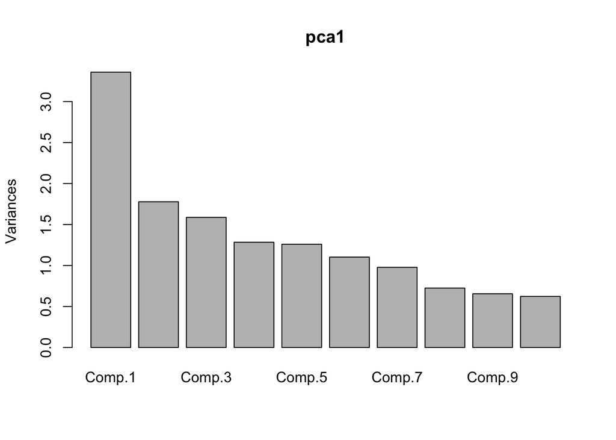

```r
plot(pca1)
```

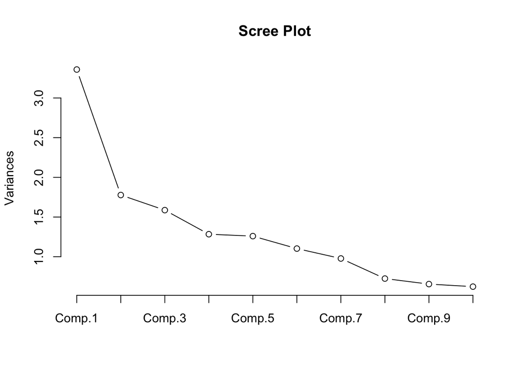

```r
screeplot(pca1, type="line", main="Scree Plot")
```

So with this graph we can see where there is a “break” in the plot and the rest of the are factors are therefore explaining less variation then the others.

Now you can see the Biplot of score variables

[figure not shown]

```r
biplot(pca1)
```

Here we get the Scores of the components

```r
pca1$scores[1:20,]
```

```
##              Comp.1       Comp.2      Comp.3      Comp.4     Comp.5
##  [1,] -2.9519848932 -0.936116715 -0.56919558  0.16510465 -1.3405508
##  [2,] -2.0948489922  0.107026515 -0.42859406  1.13013418 -0.4723147
##  [3,] -1.5106292095  0.120216482 -0.39384351 -0.07913030  0.3227832
##  [4,]  1.9193420748 -1.557800271 -0.01790636  1.05224747  1.4925952
##  [5,]  2.0069097171 -1.522420155 -0.03346796  0.11279790  0.9379758
##  [6,]  2.7227684118 -1.206211210 -0.96275202  0.56206488  0.6339846
##  [7,]  0.0831209568  0.487171889  1.55732586  0.51312841 -0.1133504
##  [8,] -0.1899864770  0.241574208  1.51972667  1.45596264  0.3669555
##  [9,]  0.0003643066  0.211838489 -1.25545204 -0.08823681  0.3372160
## [10,] -2.1964669736  0.240631984 -0.03941317  0.48797398  1.0141998
## [11,] -0.8612060196  1.551453330  0.52976178 -0.20076160  0.5696957
## [12,]  0.2304884140  2.233633406 -0.35207620 -0.68638707 -0.1846779
## [13,]  0.5178862667 -0.003354648 -0.01028525 -1.77211968  1.2363865
## [14,] -0.7739183764  1.212755613  1.15169839 -0.07716235  0.3617401
```

[output cut: 48 more lines]

So we use CPA when there is a sufficient correlation between the original variables in the dataset to warrant factor/component estimation.principal components analysis and values that are 0.5 are considered satisfactory for a principal components analysis.

Now we can use the Factor analysis

```r
fa <- factanal(X, factors=5, rotation="varimax", scores="regression")
fa
```

```
##
## Call:
## factanal(x = X, factors = 5, scores = "regression", rotation = "varimax")
##
## Uniquenesses:
##              Age           female            white           in_NYC
##            0.005            0.980            0.600            0.579
## below_150poverty below_200poverty       foodstamps      work_fullyr
##            0.132            0.226            0.723            0.698
##     income_total   income_wagesal        HH_income       owner_cost
##            0.196            0.005            0.938            0.845
##          veteran          Married        divwidsep
##            0.919            0.005            0.519
##
## Loadings:
##                  Factor1 Factor2 Factor3 Factor4 Factor5
## Age               0.108           0.987
## female           -0.105
## white                    -0.108   0.113           0.610
## in_NYC                                           -0.641
## below_150poverty -0.179   0.909
## below_200poverty -0.214   0.845                  -0.117
## foodstamps        0.125  -0.459                   0.209
## work_fullyr       0.502  -0.168           0.133
## income_total      0.879           0.148
## income_wagesal    0.997
## HH_income        -0.124  -0.205
## owner_cost        0.195  -0.247           0.105   0.189
## veteran                           0.254           0.117
## Married           0.225  -0.141   0.316   0.906
## divwidsep                         0.455  -0.517
##
##                Factor1 Factor2 Factor3 Factor4 Factor5
## SS loadings      2.242   1.939   1.406   1.132   0.912
## Proportion Var   0.149   0.129   0.094   0.075   0.061
## Cumulative Var   0.149   0.279   0.372   0.448   0.509
##
## Test of the hypothesis that 5 factors are sufficient.
## The chi square statistic is 36067.49 on 40 degrees of freedom.
## The p-value is 0
```

The numbers are now used to see which have the highest number and these (We want the fewest variables for each factor) and can be combined. Now these factors can be used instead of the original variables. This method however can be tricky as it there can be trade-off between having as factors as possible and completeness.